# Capestone Project : Cervical Cancer

Cervical cancer is a cancer arising from the cervix. It is due to the abnormal growth of cells that can invade or spread to other parts of the body. Early on, typically no symptoms are seen. Later symptoms may include abnormal vaginal bleeding, pelvic pain, or pain during sexual intercourse.

Worldwide, cervical cancer is both the fourth-most common cause of cancer and the fourth-most common cause of death from cancer in women. In 2012, an estimated 528,000 cases of cervical cancer occurred, with 266,000 deaths. This is about 8% of the total cases and total deaths from cancer. About 70% of cervical cancers occur in developing countries. In low-income countries, it is one of the most common causes of cancer death. In developed countries, the widespread use of cervical screening programs has dramatically reduced rates of cervical cancer. Source: [Cervical cancer](https://en.wikipedia.org)

## Index

- Step 0 : Data Collection & Pre-Processing
- Step 1 : Import Dataset
- Step 2 : Create CNN to classify Data Set
- Step 3 : Create CNN to Classify Data Set(Using transfer learning)
- Step 4 : Analysing results
- Step 5 : Conclusion

## Data Collection & Pre-Processing

The data has been collected from Kaggle's [Cervical Cancer Screening Competition](https://www.kaggle.com/c/intel-mobileodt-cervical-cancer-screening/data). The dataset consists of collection of images of each type of cervix. The Task at hand is to classify the images in to there proper types.

As a part of pre processing i had removed a lot of images which were either blurry, or the cervix portion was not clearly visible. In this process i ended up getting rid of 20% of the images.

Find the pre-processed data at [Google Drive](https://drive.google.com/open?id=1Ni8qez8yhfozfxTniQr8R-72O3ji9YqY)

## Import Dataset

In the code cell below, dataset of different images is imported. Few variables through the use of the `load_files` function from the scikit-learn library are populated:

```python
from sklearn.datasets import load_files
from keras.utils import np_utils
import numpy as np
from glob import glob

# define function to load train, test, and validation datasets
def load_dataset(path):
    data = load_files(path)
    cervix_files = np.array(data['filenames'])
    cervix_targets = np_utils.to_categorical(np.array(data['target']), 3)
    return cervix_files, cervix_targets

train_files, train_targets = load_dataset('train')
test_files, test_targets = load_dataset('test')
validate_files, validate_targets = load_dataset('validate')

# load list of dog names
cervix_types = [item[6:-1] for item in sorted(glob("train/*/"))]

# print statistics about the dataset
print('There are %d total cervix types.' % len(cervix_types))
print('There are %s total dog images.\n' % len(np.hstack([train_files, validate_files, test_files])))
print('There are %d training cervix images.' % len(train_files))
print('There are %d testing cervix images.' % len(test_files))
print('There are %d validation cervix images.' % len(validate_files))
```

```
There are 3 total cervix types.
There are 1424 total dog images.

There are 1060 training cervix images.
There are 182 testing cervix images.
There are 182 validation cervix images.
```

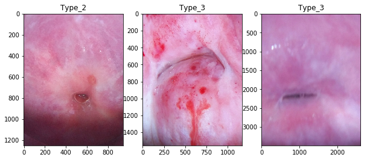

```python
import matplotlib.image as mpimg
import matplotlib.pyplot as plt

samples = [(train_files[199], train_targets[199]), (train_files[108], train_targets[108]), (train_files[9], train_targets[9])]
fig, ax = plt.subplots(1,3, figsize=(10,10), gridspec_kw={"hspace":0.9})
y = 0
for sample, sample_title in samples:
    img = mpimg.imread(sample)
    ax[y].imshow(img)
    ax[y].set_title(cervix_types[np.argmax(sample_title)])
    y+=1
plt.show()
```

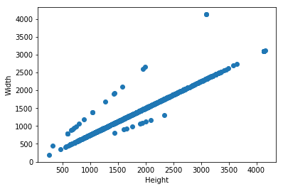

```python
#Plot the shape of all the image
import cv2
height = list()
width = list()
for image in train_files:
    img = cv2.imread(image)
    height.append(img.shape[0])
    width.append(img.shape[1])
plt.scatter(height, width)
plt.xlabel("Height")
plt.ylabel("Width")
plt.savefig('saved_models/height_width_graph.png')
plt.show()
```

## Create CNN to classify Data Set

```python
from keras.preprocessing import image
from tqdm import tqdm

def path_to_tensor(img_path):
    # loads RGB image as PIL.Image.Image type
    img = image.load_img(img_path, target_size=(512, 512))
    # convert PIL.Image.Image type to 3D tensor with shape (224, 224, 3)
    x = image.img_to_array(img)
    # convert 3D tensor to 4D tensor with shape (1, 224, 224, 3) and return 4D tensor
    return np.expand_dims(x, axis=0)

def paths_to_tensor(img_paths):
    list_of_tensors = [path_to_tensor(img_path) for img_path in tqdm(img_paths)]
    return np.vstack(list_of_tensors)
```

```python
from PIL import ImageFile
ImageFile.LOAD_TRUNCATED_IMAGES = True

# pre-process the data for Keras
train_tensors = paths_to_tensor(train_files).astype('float32')/255
valid_tensors = paths_to_tensor(validate_files).astype('float32')/255
test_tensors = paths_to_tensor(test_files).astype('float32')/255
```

[output not shown]

```python
from keras.layers import Conv2D, MaxPooling2D, GlobalAveragePooling2D
from keras.layers import Dropout, Flatten, Dense
from keras.models import Sequential

model = Sequential()
model.add(Conv2D(filters=32, kernel_size=5, padding='same', strides=2, activation='relu',
                        input_shape=(512, 512, 3)))
model.add(Conv2D(filters=32, kernel_size=3, padding='same', strides=1, activation='relu'))
model.add(Dropout(0.2))
model.add(MaxPooling2D(pool_size=2, strides=2))

model.add(Conv2D(filters=64, kernel_size=3, padding='same', strides=1, activation='relu'))
model.add(Conv2D(filters=64, kernel_size=3, padding='same', strides=1, activation='relu'))
model.add(Dropout(0.2))
model.add(MaxPooling2D(pool_size=2, strides=2))

model.add(Conv2D(filters=96, kernel_size=3, padding='same', strides=1, activation='relu'))
model.add(Conv2D(filters=96, kernel_size=3, padding='same', strides=1, activation='relu'))
model.add(Dropout(0.2))
model.add(MaxPooling2D(pool_size=2, strides=2))

model.add(Conv2D(filters=128, kernel_size=3, padding='same', strides=1, activation='relu'))
model.add(Conv2D(filters=128, kernel_size=3, padding='same', strides=1, activation='relu'))
model.add(Dropout(0.2))
model.add(MaxPooling2D(pool_size=2, strides=2))
model.add(GlobalAveragePooling2D())
model.add(Dense(3, activation='softmax'))

model.summary()
```

```
_________________________________________________________________
Layer (type)                 Output Shape              Param #
=================================================================
conv2d_9 (Conv2D)            (None, 256, 256, 32)      2432
_________________________________________________________________
conv2d_10 (Conv2D)           (None, 256, 256, 32)      9248
_________________________________________________________________
dropout_1 (Dropout)          (None, 256, 256, 32)      0
_________________________________________________________________
max_pooling2d_5 (MaxPooling2 (None, 128, 128, 32)      0
_________________________________________________________________
conv2d_11 (Conv2D)           (None, 128, 128, 64)      18496
_________________________________________________________________
conv2d_12 (Conv2D)           (None, 128, 128, 64)      36928
_________________________________________________________________
dropout_2 (Dropout)          (None, 128, 128, 64)      0
_________________________________________________________________
max_pooling2d_6 (MaxPooling2 (None, 64, 64, 64)        0
_________________________________________________________________
conv2d_13 (Conv2D)           (None, 64, 64, 96)        55392
_________________________________________________________________
conv2d_14 (Conv2D)           (None, 64, 64, 96)        83040
_________________________________________________________________
dropout_3 (Dropout)          (None, 64, 64, 96)        0
_________________________________________________________________
max_pooling2d_7 (MaxPooling2 (None, 32, 32, 96)        0
_________________________________________________________________
conv2d_15 (Conv2D)           (None, 32, 32, 128)       110720
_________________________________________________________________
conv2d_16 (Conv2D)           (None, 32, 32, 128)       147584
_________________________________________________________________
dropout_4 (Dropout)          (None, 32, 32, 128)       0
_________________________________________________________________
max_pooling2d_8 (MaxPooling2 (None, 16, 16, 128)       0
_________________________________________________________________
global_average_pooling2d_2 ( (None, 128)               0
_________________________________________________________________
dense_2 (Dense)              (None, 3)                 387
=================================================================
Total params: 464,227
Trainable params: 464,227
Non-trainable params: 0
_________________________________________________________________
```

```python
model.compile(optimizer='rmsprop', loss='categorical_crossentropy', metrics=['accuracy'])
```

```python
from keras.callbacks import ModelCheckpoint

epochs = 50

checkpointer = ModelCheckpoint(filepath='saved_models/weights.best.trail_four.hdf5',
                               verbose=1, save_best_only=True)

history = model.fit(train_tensors, train_targets,
          validation_data=(valid_tensors, validate_targets),
          epochs=epochs, batch_size=20, callbacks=[checkpointer], verbose=1)
```

```
Train on 1060 samples, validate on 182 samples

Epoch 00001: val_loss improved from inf to 1.05444, saving model to saved_models/weights.best.trail_four.hdf5

Epoch 00002: val_loss improved from 1.05444 to 1.02483, saving model to saved_models/weights.best.trail_four.hdf5

Epoch 00003: val_loss improved from 1.02483 to 1.02420, saving model to saved_models/weights.best.trail_four.hdf5

Epoch 00004: val_loss did not improve from 1.02420

Epoch 00005: val_loss did not improve from 1.02420

Epoch 00006: val_loss did not improve from 1.02420

Epoch 00007: val_loss did not improve from 1.02420

Epoch 00008: val_loss did not improve from 1.02420

Epoch 00009: val_loss did not improve from 1.02420

Epoch 00010: val_loss did not improve from 1.02420

Epoch 00011: val_loss did not improve from 1.02420

Epoch 00012: val_loss did not improve from 1.02420

Epoch 00013: val_loss improved from 1.02420 to 0.97764, saving model to saved_models/weights.best.trail_four.hdf5

Epoch 00014: val_loss did not improve from 0.97764

Epoch 00015: val_loss did not improve from 0.97764

Epoch 00016: val_loss improved from 0.97764 to 0.95627, saving model to saved_models/weights.best.trail_four.hdf5

Epoch 00017: val_loss did not improve from 0.95627

Epoch 00018: val_loss improved from 0.95627 to 0.95187, saving model to saved_models/weights.best.trail_four.hdf5

Epoch 00019: val_loss improved from 0.95187 to 0.90854, saving model to saved_models/weights.best.trail_four.hdf5

```

[output cut: 46 more lines]

```
Epoch 00043: val_loss did not improve from 0.77908

Epoch 00044: val_loss did not improve from 0.77908

Epoch 00045: val_loss did not improve from 0.77908

Epoch 00046: val_loss did not improve from 0.77908

Epoch 00047: val_loss did not improve from 0.77908

Epoch 00048: val_loss did not improve from 0.77908

Epoch 00049: val_loss did not improve from 0.77908

Epoch 00050: val_loss did not improve from 0.77908
```

```python
model.load_weights('saved_models/weights.best.trail_four.hdf5')
```

```python
# get index of predicted dog breed for each image in test set
cervix_type_custom = [np.argmax(model.predict(np.expand_dims(tensor, axis=0))) for tensor in test_tensors]

# report test accuracy
test_accuracy = 100*np.sum(np.array(cervix_type_custom)==np.argmax(test_targets, axis=1))/len(cervix_type_custom)
print('Test accuracy: %.4f%%' % test_accuracy)
```

```
Test accuracy: 56.5934%
```

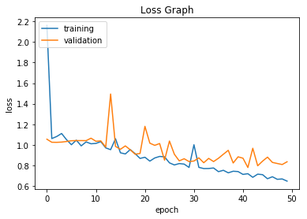

```python
# summarize history for accuracy
plt.plot(history.history['loss'])
plt.plot(history.history['val_loss'])
plt.title('Loss Graph')
plt.ylabel('loss')
plt.xlabel('epoch')
plt.legend(['training', 'validation'], loc='upper left')
plt.savefig('saved_models/loss_graph.png')
plt.show()
```

## Create CNN to Classify Data Set (Using transfer learning)

For Transfer learning i have made used of VGG-16 which is pre-trained on IMAGE NET. Tranfer learning is best suited when one has small data, which is exactly my case.  
I have chopped off the top fully connected layer and instead have added my own fully connected network at the top of it. I have also frozen weights of all the convolutional layers.

```python
from keras.applications.vgg16 import VGG16
from keras.models import Model
from keras.layers import Input, Dense

input_value = Input(shape=(512, 512, 3))
vgg16_model = VGG16(input_tensor=input_value, include_top=False, weights='imagenet')
last_layer = vgg16_model.output
layer = GlobalAveragePooling2D()(last_layer)
layer = Dense(512, activation='relu')(layer)
layer = Dropout(0.2)(layer)
output = Dense(3, activation='softmax')(layer)
custom_model = Model(inputs= input_value, outputs= output)

for layer in custom_model.layers[:-4]:
    layer.trainable = False

custom_model.summary()
```

```
_________________________________________________________________
Layer (type)                 Output Shape              Param #
=================================================================
input_5 (InputLayer)         (None, 512, 512, 3)       0
_________________________________________________________________
block1_conv1 (Conv2D)        (None, 512, 512, 64)      1792
_________________________________________________________________
block1_conv2 (Conv2D)        (None, 512, 512, 64)      36928
_________________________________________________________________
block1_pool (MaxPooling2D)   (None, 256, 256, 64)      0
_________________________________________________________________
block2_conv1 (Conv2D)        (None, 256, 256, 128)     73856
_________________________________________________________________
block2_conv2 (Conv2D)        (None, 256, 256, 128)     147584
_________________________________________________________________
block2_pool (MaxPooling2D)   (None, 128, 128, 128)     0
_________________________________________________________________
block3_conv1 (Conv2D)        (None, 128, 128, 256)     295168
_________________________________________________________________
block3_conv2 (Conv2D)        (None, 128, 128, 256)     590080
_________________________________________________________________
block3_conv3 (Conv2D)        (None, 128, 128, 256)     590080
_________________________________________________________________
block3_pool (MaxPooling2D)   (None, 64, 64, 256)       0
_________________________________________________________________
block4_conv1 (Conv2D)        (None, 64, 64, 512)       1180160
_________________________________________________________________
block4_conv2 (Conv2D)        (None, 64, 64, 512)       2359808
_________________________________________________________________
block4_conv3 (Conv2D)        (None, 64, 64, 512)       2359808
_________________________________________________________________
block4_pool (MaxPooling2D)   (None, 32, 32, 512)       0
_________________________________________________________________
block5_conv1 (Conv2D)        (None, 32, 32, 512)       2359808
_________________________________________________________________
block5_conv2 (Conv2D)        (None, 32, 32, 512)       2359808
_________________________________________________________________
block5_conv3 (Conv2D)        (None, 32, 32, 512)       2359808
_________________________________________________________________
block5_pool (MaxPooling2D)   (None, 16, 16, 512)       0
_________________________________________________________________
global_average_pooling2d_6 ( (None, 512)               0
_________________________________________________________________
dense_10 (Dense)             (None, 512)               262656
_________________________________________________________________
dropout_5 (Dropout)          (None, 512)               0
_________________________________________________________________
dense_11 (Dense)             (None, 3)                 1539
=================================================================
Total params: 14,978,883
Trainable params: 264,195
Non-trainable params: 14,714,688
_________________________________________________________________
```

```python
custom_model.compile(optimizer='rmsprop', loss='categorical_crossentropy', metrics=['accuracy'])
```

```python
from keras.callbacks import ModelCheckpoint

epochs = 20
checkpointer = ModelCheckpoint(filepath='saved_models/weights.best.vgg16.hdf5',
                               verbose=1, save_best_only=True)

custom_model.fit(train_tensors, train_targets,
          validation_data=(valid_tensors, validate_targets),
          epochs=epochs, batch_size=20, callbacks=[checkpointer], verbose=1)
```

```
Train on 1060 samples, validate on 182 samples

Epoch 00001: val_loss improved from inf to 1.00474, saving model to saved_models/weights.best.vgg16.hdf5

Epoch 00002: val_loss improved from 1.00474 to 0.98655, saving model to saved_models/weights.best.vgg16.hdf5

Epoch 00003: val_loss did not improve from 0.98655

Epoch 00004: val_loss improved from 0.98655 to 0.98311, saving model to saved_models/weights.best.vgg16.hdf5

Epoch 00005: val_loss did not improve from 0.98311

Epoch 00006: val_loss did not improve from 0.98311

Epoch 00007: val_loss did not improve from 0.98311

Epoch 00008: val_loss improved from 0.98311 to 0.97731, saving model to saved_models/weights.best.vgg16.hdf5

Epoch 00009: val_loss did not improve from 0.97731

Epoch 00010: val_loss did not improve from 0.97731

Epoch 00011: val_loss did not improve from 0.97731

Epoch 00012: val_loss did not improve from 0.97731

Epoch 00013: val_loss did not improve from 0.97731

Epoch 00014: val_loss did not improve from 0.97731

Epoch 00015: val_loss did not improve from 0.97731

Epoch 00016: val_loss did not improve from 0.97731

Epoch 00017: val_loss did not improve from 0.97731

Epoch 00018: val_loss did not improve from 0.97731

Epoch 00019: val_loss did not improve from 0.97731

Epoch 00020: val_loss did not improve from 0.97731
```

```
<keras.callbacks.History at 0x7f6de5f1f898>
```

```python
custom_model.load_weights('saved_models/weights.best.vgg16.hdf5')
# get index of predicted dog breed for each image in test set
cervix_type_vgg16 = [np.argmax(custom_model.predict(np.expand_dims(tensor, axis=0))) for tensor in test_tensors]

# report test accuracy
test_accuracy = 100*np.sum(np.array(cervix_type_vgg16)==np.argmax(test_targets, axis=1))/len(cervix_type)
print('Test accuracy: %.4f%%' % test_accuracy)
```

```
Test accuracy: 46.1538%
```

## Analysing results

```python
import seaborn as sns
import pandas as pd

def plot_result(prediction, title):
    truth_values = np.array(prediction)==np.argmax(test_targets, axis=1)
    actual_types = [ cervix_types[i] for i in np.argmax(test_targets, axis=1)]
    result = pd.DataFrame({
        'Types': actual_types,
        'Result': truth_values
    })

    ax = sns.countplot(x="Types", hue="Result", data=result)
    ax.set_title(title)
```

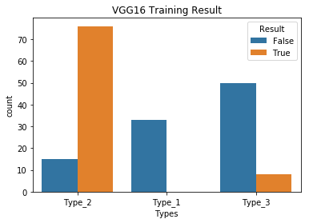

```python
plot_result(cervix_type_vgg16, 'VGG16 Training Result')
```

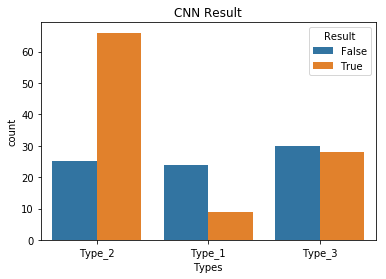

```python
plot_result(cervix_type_custom, 'CNN Result')
plt.savefig('saved_models/cnn_result.png')
```